# EP10-respuesta-equipo-2

EJEMPLO

2025-06-09

### LECTURA DE ARCHIVO

```r
datos <- read.csv2("EP09 Datos.csv")
```

# PREGUNTAS:

### Pregunta 1:

> Asegurando reproducibilidad, seleccionar una muestra de 150 mujeres (si su n° de equipo es un número par) o 150 hombres (si su n° de equipo es impar), asegurando que la mitad tenga estado nutricional “sobrepeso” y la otra mitad “no sobrepeso” en cada caso. Dividir esta muestra en dos conjuntos: los datos de 100 personas (50 con EN “sobrepeso”) para utilizar en la construcción de los modelos y 50 personas (25 con EN “sobrepeso”) para poder evaluarlos.

```r
set.seed(0075)

ICM <- datos$Weight / ((datos$Height * 0.01)^2)
datos_con_ICM <- cbind(datos, ICM)

datos_con_ICM <- datos_con_ICM %>%
  mutate(EN = factor(ifelse(ICM >= 23.2, "sobrepeso", "no sobrepeso"),
                     levels = c("no sobrepeso", "sobrepeso")))

mitad_sobrepeso <- datos_con_ICM %>%
  filter(Gender == 1 & ICM >= 23.2) %>%
  sample_n(75, replace = FALSE)

mitad_no_sobrep <- datos_con_ICM %>%
  filter(Gender == 1 & ICM < 23.2) %>%
  sample_n(75, replace = FALSE)

sobrepeso_entrenamiento <- mitad_sobrepeso %>% slice_head(n = 50)
no_sobrepeso_entrenamiento <- mitad_no_sobrep %>% slice_head(n = 50)

sobrepeso_prueba <- mitad_sobrepeso %>% slice_tail(n = 25)
no_sobrepeso_prueba <- mitad_no_sobrep %>% slice_tail(n = 25)

grup_entrenamiento <- rbind(sobrepeso_entrenamiento, no_sobrepeso_entrenamiento) %>%
  select(-Gender) %>%
  sample_frac(1L)

grup_prueba <- rbind(sobrepeso_prueba, no_sobrepeso_prueba) %>%
  select(-Gender) %>%
  sample_frac(1L)
```

### Pregunta 2:

> Recordar las ocho posibles variables predictoras seleccionadas de forma aleatoria en el ejercicio anterior.

La 8 variables predictoras seleccionadas de forma aleatoria eran:

- Ankle.Minimum.Girth
- Chest.depth
- Hip.Girth
- Chest.Girth
- Biacromial.diameter
- Calf.Maximum.Girth
- Elbows.diameter
- Knees.diameter

### Pregunta 3:

> Seleccionar, de las otras variables, una que el equipo considere que podría ser útil para predecir la clase EN, justificando bien esta selección (idealmente con literatura).

```r
nombres_variables = c("Ankle.Minimum.Girth", "Hip.Girth", "Chest.depth", "Chest.Girth", "Biacromial.diameter", "Calf.Maximum.Girth", "Elbows.diameter", "Knees.diameter")


restantes = setdiff(colnames(datos_con_ICM), c(nombres_variables, "EN" ,"ICM"))
print(restantes)
```

```
##  [1] "Biiliac.diameter"        "Bitrochanteric.diameter"
##  [3] "Chest.diameter"          "Wrists.diameter"
##  [5] "Ankles.diameter"         "Shoulder.Girth"
##  [7] "Waist.Girth"             "Navel.Girth"
##  [9] "Thigh.Girth"             "Bicep.Girth"
## [11] "Forearm.Girth"           "Knee.Girth"
## [13] "Wrist.Minimum.Girth"     "Age"
## [15] "Weight"                  "Height"
## [17] "Gender"
```

Se decide usar “Waist.Girth”, gracias a la información presente en el siguiente documento:

https://portal.amelica.org/ameli/journal/101/1014218004/html/

Donde se menciona que la circunferencia de la cintura (Waist.Girth) es un indicador importante para el sobrepeso, ya que esta es la mejor variable con la cual se puede estimar el valor de grasa visceral, factor que es un predictor importante de riesgo metabólico y cardiovascular en pacientes con sobrepeso.

Es por lo anteriormente mencionado, que Waist.Girth es una variable predictora relevante para el estado nutricional (EN).

### Pregunta 4:

> Usando el entorno R, construir un modelo de regresión logística con el predictor seleccionado en el paso anterior y utilizando de la muestra obtenida.

```r
set.seed(0075)


modelo <- glm(EN ~ Waist.Girth, family = binomial(link = "logit"), data = grup_entrenamiento)
print(summary(modelo))
```

```
##
## Call:
## glm(formula = EN ~ Waist.Girth, family = binomial(link = "logit"),
##     data = grup_entrenamiento)
##
## Coefficients:
##              Estimate Std. Error z value Pr(>|z|)
## (Intercept) -21.16056    4.13194  -5.121 3.04e-07 ***
## Waist.Girth   0.25681    0.05042   5.094 3.51e-07 ***
## ---
## Signif. codes:  0 '***' 0.001 '**' 0.01 '*' 0.05 '.' 0.1 ' ' 1
##
## (Dispersion parameter for binomial family taken to be 1)
##
##     Null deviance: 138.629  on 99  degrees of freedom
## Residual deviance:  83.944  on 98  degrees of freedom
## AIC: 87.944
##
## Number of Fisher Scoring iterations: 5
```

```r
ROC_ent <- roc(grup_entrenamiento$EN, fitted(modelo),
               levels = c("no sobrepeso", "sobrepeso"),
               direction = "<")

g_ROC_ent <- ggroc(ROC_ent, aes = "steelblue")
```

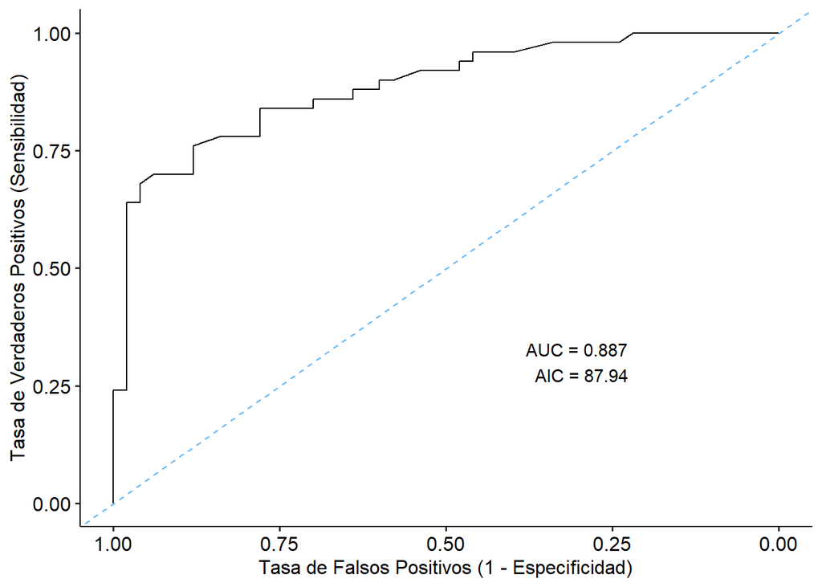

```r
g_ROC_ent <- g_ROC_ent + geom_abline(slope = 1, intercept = 1,
                                     linetype = "dashed", color = "steelblue1")
g_ROC_ent <- g_ROC_ent + xlab("Tasa de Falsos Positivos (1 - Especificidad)") + ylab("Tasa de Verdaderos Positivos (Sensibilidad)")
texto_ent <- paste("AUC =", round(auc(ROC_ent), 3), "\n", "AIC =", round(AIC(modelo), 2))
g_ROC_ent <- g_ROC_ent + annotate("text", x = 0.3, y = 0.3, label = texto_ent)
g_ROC_ent <- g_ROC_ent + theme_pubr()
print(g_ROC_ent)
```

Del modelo obtenido es posible observar que:

La variable predictora “Waist.Girth” es significativa para el modelo, ya que su valor p es mucho menor a 0.05, siendo este 3.51e-07. Teniendo una alta capacidad predictiva, siendo esta 0.887, presente en el gráfico de curva ROC, teniendo una curva que se aleja mucho de la diagonal. Lo que nos permite concluir que “Waist.Girth” es un buen predictor para este modelo.

### Pregunta 5:

> Usando estas herramientas para la exploración de modelos del entorno R, buscar entre dos y cinco predictores de entre las variables seleccionadas al azar, recordadas en el punto 2, para agregar al modelo obtenido en el paso 4. Para esto, si - si su n° de equipo es 1 o 2: utilice selección hacia adelante, sin usar la función step().

Se decide para ir probando variables, en vez de utilizar update, ir manualmente probando y agregando variables que reduzcan la mayor cantidad posible el AIC y asi en la siguiente iteracion, removiendo la variable seleccionada del pool de variables, el criterio es el siguiente:

Si Delta < 0, la variable mejora el modelo Si Delta > 0, la variable empeora el modelo

En el caso que exista mas de una variable con Delta negativo, se tomara la que tenga mayor magnitud.

### Primera iteracion

```r
nombres_variables = c("Ankle.Minimum.Girth", "Hip.Girth", "Chest.depth", "Chest.Girth", "Biacromial.diameter", "Calf.Maximum.Girth", "Elbows.diameter", "Knees.diameter")
modelo_base <- modelo

for(var in nombres_variables) {
  formula_temp <- paste("EN ~ Waist.Girth +", var)
  modelo_temp <- glm(formula_temp, family = binomial(link = "logit"),
                    data = grup_entrenamiento)

  print(paste(var, "AIC =", round(AIC(modelo_temp), 2), "Delta =", round(AIC(modelo_temp) - AIC(modelo_base), 2)))
}
```

```
## [1] "Ankle.Minimum.Girth AIC = 88.9 Delta = 0.96"
## [1] "Hip.Girth AIC = 85.64 Delta = -2.3"
## [1] "Chest.depth AIC = 88.53 Delta = 0.58"
## [1] "Chest.Girth AIC = 84.02 Delta = -3.93"
## [1] "Biacromial.diameter AIC = 89.94 Delta = 2"
## [1] "Calf.Maximum.Girth AIC = 70.33 Delta = -17.62"
## [1] "Elbows.diameter AIC = 89.6 Delta = 1.65"
## [1] "Knees.diameter AIC = 86.16 Delta = -1.78"
```

Se repite el proceso, eliminando la variable que tenga su Delta mas negativo, en este caso es Calf.Maximum.Girth

### Segunda Iteracion

```r
modelo_2pred <- glm(EN ~ Waist.Girth + Calf.Maximum.Girth,
                   family = binomial(link = "logit"), data = grup_entrenamiento)

restantes = setdiff(nombres_variables, "Calf.Maximum.Girth")
for(var in restantes) {
  formula_temp <- paste("EN ~ Waist.Girth + Calf.Maximum.Girth +", var)
  modelo_temp <- glm(formula_temp, family = binomial(link = "logit"),
                    data = grup_entrenamiento)

  delta <- AIC(modelo_temp) - AIC(modelo_2pred)
  print(paste(var, "AIC =", round(AIC(modelo_temp), 2), "Delta =", round(AIC(modelo_temp) - AIC(modelo_base), 2)))
}
```

```
## [1] "Ankle.Minimum.Girth AIC = 70.7 Delta = -17.25"
## [1] "Hip.Girth AIC = 72.28 Delta = -15.67"
## [1] "Chest.depth AIC = 72.26 Delta = -15.68"
## [1] "Chest.Girth AIC = 68.46 Delta = -19.48"
## [1] "Biacromial.diameter AIC = 70.26 Delta = -17.69"
## [1] "Elbows.diameter AIC = 71.2 Delta = -16.74"
## [1] "Knees.diameter AIC = 72.31 Delta = -15.63"
```

Se repite el proceso, en este caso es Chest.Girth

### Tercera Iteracion

```r
modelo_3pred = glm(EN ~ Waist.Girth + Calf.Maximum.Girth + Chest.Girth,
                   family = binomial(link = "logit"), data = grup_entrenamiento)

restantes = setdiff(restantes, "Chest.Girth")
for(var in restantes) {
  formula_temp <- paste("EN ~ Waist.Girth + Calf.Maximum.Girth + Chest.Girth +", var)
  modelo_temp <- glm(formula_temp, family = binomial(link = "logit"),
                    data = grup_entrenamiento)

  delta <- AIC(modelo_temp) - AIC(modelo_3pred)
  print(paste(var, "AIC =", round(AIC(modelo_temp), 2), "Delta =", round(delta, 2)))
}
```

```
## [1] "Ankle.Minimum.Girth AIC = 68.26 Delta = -0.2"
## [1] "Hip.Girth AIC = 69.92 Delta = 1.46"
## [1] "Chest.depth AIC = 69.92 Delta = 1.46"
## [1] "Biacromial.diameter AIC = 66.16 Delta = -2.3"
## [1] "Elbows.diameter AIC = 66.15 Delta = -2.31"
## [1] "Knees.diameter AIC = 70.12 Delta = 1.66"
```

```r
modelo_4_final <- glm(EN ~ Waist.Girth + Calf.Maximum.Girth + Biacromial.diameter + Chest.Girth,
                   family = binomial(link = "logit"), data = grup_entrenamiento)

print(summary(modelo_4_final))
```

```
##
## Call:
## glm(formula = EN ~ Waist.Girth + Calf.Maximum.Girth + Biacromial.diameter +
##     Chest.Girth, family = binomial(link = "logit"), data = grup_entrenamiento)
##
## Coefficients:
##                      Estimate Std. Error z value Pr(>|z|)
## (Intercept)         -43.41167   10.54887  -4.115 3.87e-05 ***
## Waist.Girth           0.13270    0.06114   2.170 0.029985 *
## Calf.Maximum.Girth    0.89480    0.26542   3.371 0.000748 ***
## Biacromial.diameter  -0.37541    0.18787  -1.998 0.045694 *
## Chest.Girth           0.15364    0.06766   2.271 0.023155 *
## ---
## Signif. codes:  0 '***' 0.001 '**' 0.01 '*' 0.05 '.' 0.1 ' ' 1
##
## (Dispersion parameter for binomial family taken to be 1)
##
##     Null deviance: 138.629  on 99  degrees of freedom
## Residual deviance:  56.163  on 95  degrees of freedom
## AIC: 66.163
##
## Number of Fisher Scoring iterations: 6
```

Tras la realización de este modelo es posible observar que:

Todos los predictores son significativos, ya que sus valores p son menores a 0.05, lo que indica que tienen un impacto significativo en la predicción del estado nutricional (EN). Además, el modelo entrega un AIC de 66.163, lo que indica que el modelo es relativamente bueno en términos de ajuste.

### Pregunta 6

> Evaluar la confiabilidad de los modelos (i.e. que tengan un buen nivel de ajuste y son generalizables) y “arreglarlos” en caso de que tengan algún problema.

Para evaluar la confiabilidad de los modelos de regresión logística, debemos considerar varios supuestos y condiciones:

> 1. Debe existir una relación lineal entre los predictores y la respuesta transformada.

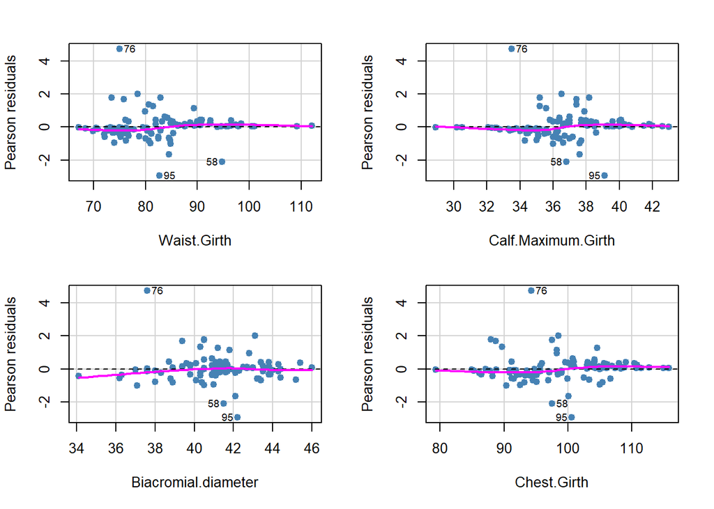

```
##                     Test stat Pr(>|Test stat|)
## Waist.Girth            0.0008           0.9776
## Calf.Maximum.Girth     0.5443           0.4607
## Biacromial.diameter    1.2018           0.2730
## Chest.Girth            1.0973           0.2949
```

```r
# GRAFICO DE RESIDUOS
residualPlots(modelo_4_final, terms = ~ Waist.Girth + Calf.Maximum.Girth + Biacromial.diameter + Chest.Girth,
              id = list(method = "r", n = 3, cex = 0.7, location = "lr"),
               col = "steelblue", pch = 19, col.quad = "red", fitted = FALSE)
```

Dado los resultados de los residualPlots, se puede confirmar que se cumple el supuesto de linealidad entre los predictores y la respuesta obtenida. Pues todo valor p obtenido es mayor a 0.05, lo que indica que no hay evidencia suficiente para rechazar la hipótesis nula de linealidad. Además que los gráficos no presentan curvatura.

Lo que indica que este supuesto se cumple.

> 2. Los residuos deben ser independientes entre sí.

```r
durbinWatsonTest(modelo_4_final)
```

```
##  lag Autocorrelation D-W Statistic p-value
##    1    -0.008850428      2.016094   0.898
##  Alternative hypothesis: rho != 0
```

Dado que el valor p es de 0.898, no hay evidencia para sospechar que no se esté cumpliendo la condición de independencia de los residuos

> 3. Multicolinealidad entre los predictores, que en este caso se evalúa y aborda del mismo modo que para RLM (por ejemplo, mediante el factor de inflación de la varianza o la tolerancia).

```r
vif(modelo_4_final)
```

```
##         Waist.Girth  Calf.Maximum.Girth Biacromial.diameter         Chest.Girth
##            1.190208            1.249249            1.506926            1.445165
```

Dado que los valores VIF son menores a 5 y mayores a 1, no hay evidencia de multicolinealidad preocupante entre entre los predictores del modelo.

Lo que indica que este supuesto se cumple.

> 4. Información incompleta, que se produce cuando no contamos con observaciones suficientes para todas las posibles combinaciones de predictores, en especial para algún nivel de una variable categórica.

```r
# CANTIDAD DE OBSERVACIONES EN EL MODELO
n_obs <- nrow(grup_entrenamiento)
cat("Cantidad de observaciones en el modelo:", n_obs, "\n")
```

```
## Cantidad de observaciones en el modelo: 100
```

```r
# VERICAR QUE TODO VALOR NO SEA N/A
cat("Cantidad de valores NA en el modelo:", sum(is.na(grup_entrenamiento)), "\n")
```

```
## Cantidad de valores NA en el modelo: 0
```

```r
# Verificar la cantidad de valores únicos por cada predictor numérico

grup_entrenamiento %>%
  group_by(EN) %>%
  summarise(
    biacromial_unique = n_distinct(Biacromial.diameter),
    calf_unique = n_distinct(Calf.Maximum.Girth),
    chest_unique = n_distinct(Chest.Girth),
    waist_unique = n_distinct(Waist.Girth)
  )
```

```
## # A tibble: 2 × 5
##   EN           biacromial_unique calf_unique chest_unique waist_unique
##   <fct>                    <int>       <int>        <int>        <int>
## 1 no sobrepeso                37          39           42           39
## 2 sobrepeso                   29          38           42           45
```

Como es posible observar, cada combinación de predictores presenta al menos 29 observaciones, lo que indica que no hay problemas de información incompleta en el modelo.

> 5. Separación perfecta, que ocurre cuando no hay superposición entre las clases (es decir, como vimos, cuando los predictores separan ambas clases completamente).

Es posible observar que en los graficos de residuos se puede notar que las rectas ajustadas no están desviadas de la curva local de ajuste de los datos, “lo que indica que no hay separación perfecta”.

> 6. Las estimaciones de los coeficientes del modelo no estan dominadas por casos influyentes.

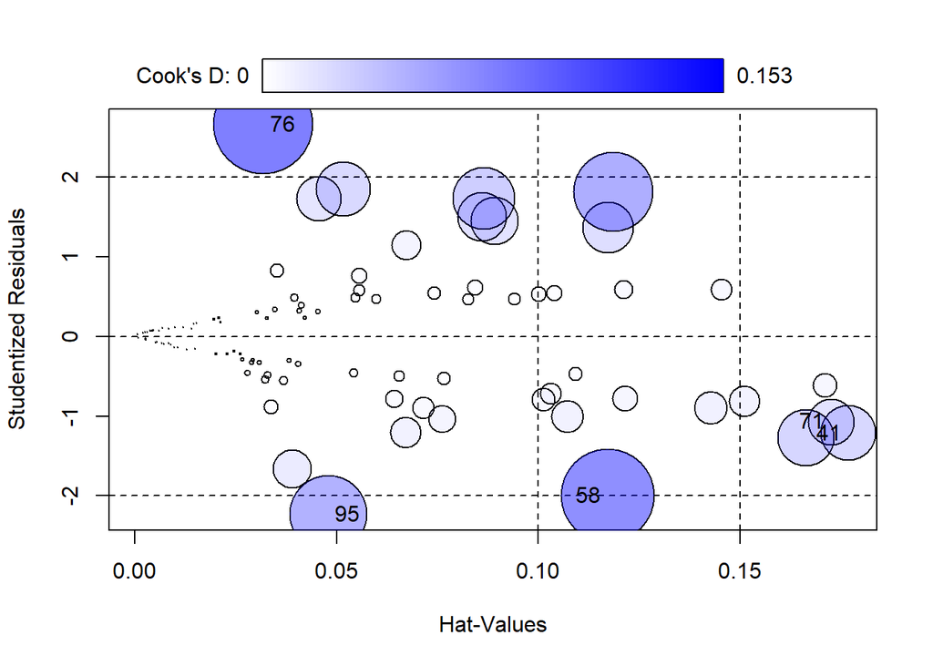

```
##      StudRes        Hat      CookD
## 41 -1.217223 0.17673577 0.04713155
## 58 -1.998056 0.11704321 0.13428459
## 71 -1.070812 0.17241613 0.03306964
## 76  2.654608 0.03193605 0.15281335
## 95 -2.232317 0.04793509 0.09205679
```

```r
influencePlot(modelo_4_final)
```

Es posible observar que si bien los puntos 41, 58, 71, 76 y 95 destacan por sobre el resto, donde la observación 76 presenta residuos(StudRes) mayor a 2, la observación 95 presenta residuos(StudRes) menor a 2, pero ninguna de las cinco observaciones supera el umbral crítico en la distancia de Cook, siendo todos estos menores a 1, por ende no se consideran altamente influyentes ni comprometen significativamente la validez del modelo.

Dado todas las condiciones se cumplen, se puede concluir que, los predictores no perjudican al modelo para que sea completamente confiable.

> 7. Usando código estándar, evaluar el poder predictivo de los modelos con los datos de las 50 personas que no se incluyeron en su construcción en términos de sensibilidad y especificidad.

```r
# Probabilidades predichas por el modelo
predicciones_prob <- predict(modelo_4_final, newdata = grup_prueba, type = "response")

# Clasificación de las probabilidades
predicciones_clase <- ifelse(predicciones_prob > 0.5, "sobrepeso", "no sobrepeso")
predicciones_clase <- factor(predicciones_clase, levels = c("no sobrepeso", "sobrepeso"))

observado <- factor(grup_prueba$EN, levels = c("no sobrepeso", "sobrepeso"))

matriz_conf <- table(Predicho = predicciones_clase, Observado = observado)

verdaderos_positivos <- matriz_conf["sobrepeso", "sobrepeso"]
falsos_negativos <- matriz_conf["no sobrepeso", "sobrepeso"]
verdaderos_negativos <- matriz_conf["no sobrepeso", "no sobrepeso"]
falsos_positivos <- matriz_conf["sobrepeso", "no sobrepeso"]

sensibilidad <- verdaderos_positivos / (verdaderos_positivos + falsos_negativos)
especificidad <- verdaderos_negativos / (verdaderos_negativos + falsos_positivos)
exactitud <- (verdaderos_positivos + verdaderos_negativos) / sum(matriz_conf)

cat("\nMatriz de Confusión:\n")
```

```
##
## Matriz de Confusión:
```

```r
print(matriz_conf)
```

```
##               Observado
## Predicho       no sobrepeso sobrepeso
##   no sobrepeso           18         5
##   sobrepeso               7        20
```

```r
cat("\nRendimiento del modelo en datos de prueba:\n")
```

```
##
## Rendimiento del modelo en datos de prueba:
```

```r
cat("Sensibilidad:", round(sensibilidad, 3), "\n")
```

```
## Sensibilidad: 0.8
```

```r
cat("Especificidad:", round(especificidad, 3), "\n")
```

```
## Especificidad: 0.72
```

```r
cat("Exactitud:", round(exactitud, 3), "\n")
```

```
## Exactitud: 0.76
```

```r
# Probabilidades predichas por el modelo en datos de entrenamiento
predicciones_prob_entrenamiento <- predict(modelo_4_final, newdata = grup_entrenamiento, type = "response")

# Clasificación de las probabilidades
predicciones_clase_entrenamiento <- ifelse(predicciones_prob_entrenamiento > 0.5, "sobrepeso", "no sobrepeso")
predicciones_clase_entrenamiento <- factor(predicciones_clase_entrenamiento, levels = c("no sobrepeso", "sobrepeso"))

# Valores observados reales
observado_entrenamiento <- factor(grup_entrenamiento$EN, levels = c("no sobrepeso", "sobrepeso"))

# Matriz de confusión
matriz_conf_entrenamiento <- table(Predicho = predicciones_clase_entrenamiento, Observado = observado_entrenamiento)

# Cálculo de métricas
verdaderos_positivos_ent <- matriz_conf_entrenamiento["sobrepeso", "sobrepeso"]
falsos_negativos_ent     <- matriz_conf_entrenamiento["no sobrepeso", "sobrepeso"]
verdaderos_negativos_ent <- matriz_conf_entrenamiento["no sobrepeso", "no sobrepeso"]
falsos_positivos_ent     <- matriz_conf_entrenamiento["sobrepeso", "no sobrepeso"]

sensibilidad_ent <- verdaderos_positivos_ent / (verdaderos_positivos_ent + falsos_negativos_ent)
especificidad_ent <- verdaderos_negativos_ent / (verdaderos_negativos_ent + falsos_positivos_ent)
exactitud_ent <- (verdaderos_positivos_ent + verdaderos_negativos_ent) / sum(matriz_conf_entrenamiento)

# Mostrar resultados
cat("\nMatriz de Confusión (Entrenamiento):\n")
```

```
##
## Matriz de Confusión (Entrenamiento):
```

```r
print(matriz_conf_entrenamiento)
```

```
##               Observado
## Predicho       no sobrepeso sobrepeso
##   no sobrepeso           46         8
##   sobrepeso               4        42
```

```r
cat("\nRendimiento del modelo en datos de entrenamiento:\n")
```

```
##
## Rendimiento del modelo en datos de entrenamiento:
```

```r
cat("Sensibilidad:", round(sensibilidad_ent, 3), "\n")
```

```
## Sensibilidad: 0.84
```

```r
cat("Especificidad:", round(especificidad_ent, 3), "\n")
```

```
## Especificidad: 0.92
```

```r
cat("Exactitud:", round(exactitud_ent, 3), "\n")
```

```
## Exactitud: 0.88
```

Como se puede observar en los resultados, ambos modelos muestran una buena capacidad predictiva, esto debido a que la sensibilidad y especificidad son relativamente altas, sin embargo, en los datos de prueba ambos valores son más bajos que en los datos de entrenamiento, lo que indica que el modelo no generaliza tan bien a nuevos datos.